# AFDMD-111 Estadística

Distribuciones de probabilidad

## Distribuciones discretas de probabilidad

Las distribuciones probabilidad se pueden clasificar en dos tipos importantes:

- Distribuciones discretas.
- Distribuciones continuas.

### Distribución de Bernoulli

Entre las distribuciones de probabilidad discretas podemos mencionar a la distribución de Bernoulli, la cual tiene la siguiente forma matemática:

$$p(k) = p^k(1-p)^{1-k}, \; \mbox{para} \; k\in (0,1)$$

En `R`, podemos simular muestras de la distribución de Bernoulli mediante el comando:

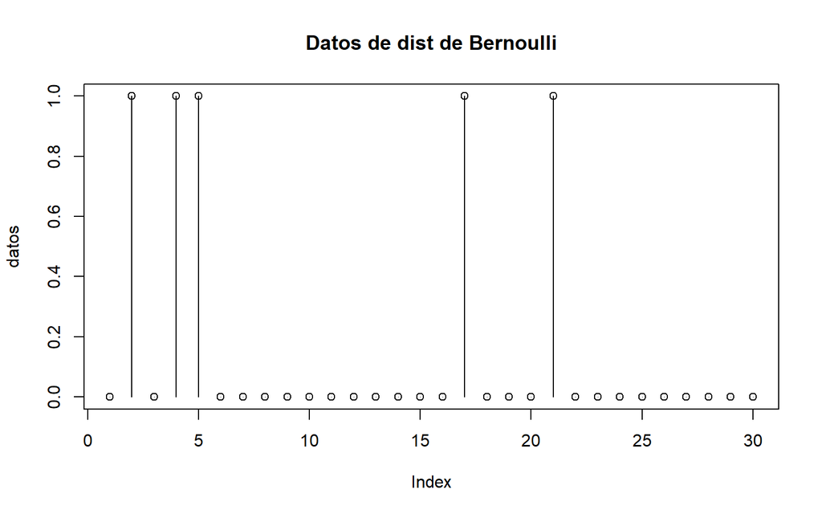

```r
# Sacamos una muestra de 30 datos Bernoulli y graficamos
datos <- rbinom(n=30, size=1, prob=0.3)
plot(datos, type="h", main="Datos de dist de Bernoulli")
points(datos)
```

En este caso size representa a $n$ que es igual a $1$. Otra distribución discreta importante es la Binomial (la de Bernoulli es un caso especial de ésta).

### Distribución Binomial

La distribución binomial representa el número de éxitos en $n$ intentos, mientras que la de Bernoulli, representa éxito o fracaso, la fórmula que representa a la distribución Binomial está dada por:

$$Pr(X=k) = {n\choose k} p^k(1-p)^{n-k}$$
En `R` podemos simular a la distribución Binomial como:

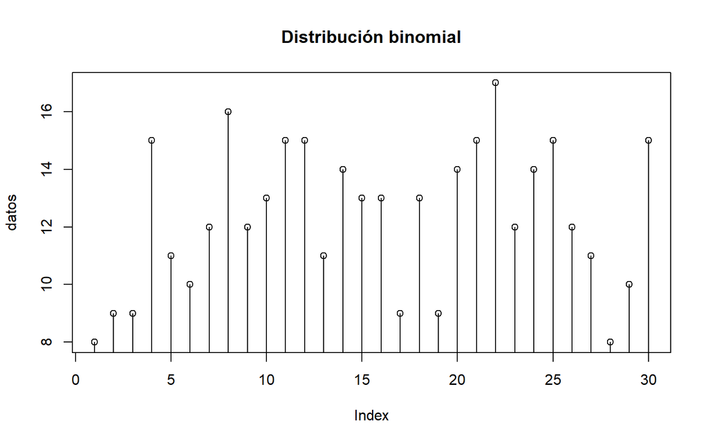

```r
datos <- rbinom(30, size=20, prob=0.6)
plot(datos, type="h", main= "Distribución binomial")
points(datos)
```

y si hacemos la probabilidad más pequeña ($p=0.1$), tenemos;

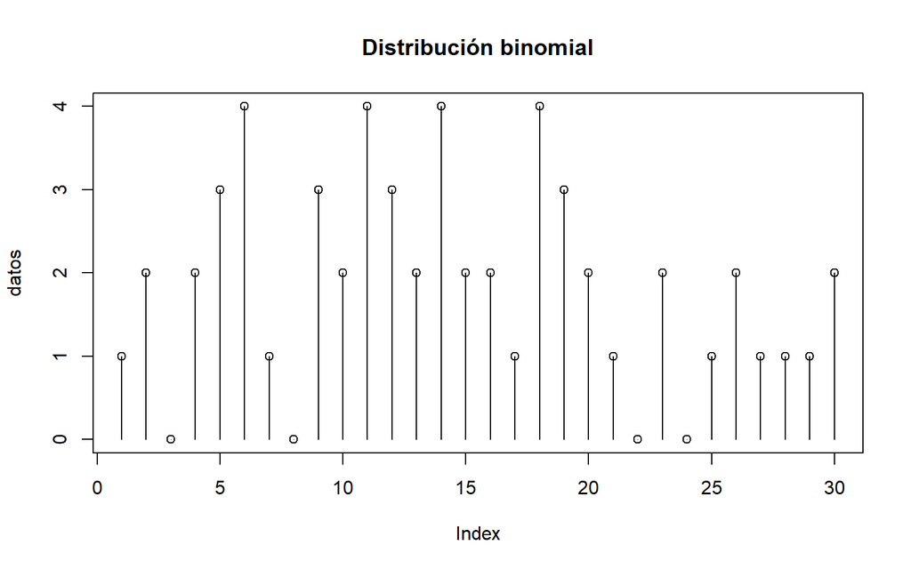

```r
datos <- rbinom(30, size=20, prob=0.1)
plot(datos, type="h", main= "Distribución binomial")
points(datos)
```

### Tarea

Investigar las siguiente distribuciones discretas y verificar cómo se pueden generar en `R` (Nota: no es necesario generarlos en `R`, es opcional).

- Distribución de Poison.

```r
# se utiliza para modelar la cantidad de eventos que ocurren en un intervalo de tiempo o espacio fijo si estos eventos ocurren con una tasa media constante y de manera independiente.
lambda <- 3
n <- 100
poisson_result <- rpois(n, lambda)
print(poisson_result)
```

```
##   [1] 3 7 3 3 4 5 5 2 4 2 4 1 2 5 0 0 2 4 2 4 1 2 4 2 2 3 7 7 1 2 1 2 2 1 3 3 2
##  [38] 3 2 3 3 3 3 4 1 7 0 3 1 4 1 4 5 3 1 4 1 3 2 2 1 1 3 2 2 3 5 7 6 2 3 5 1 3
##  [75] 4 2 2 7 4 6 1 1 3 4 5 1 1 3 3 3 1 3 2 4 1 4 2 7 3 2
```

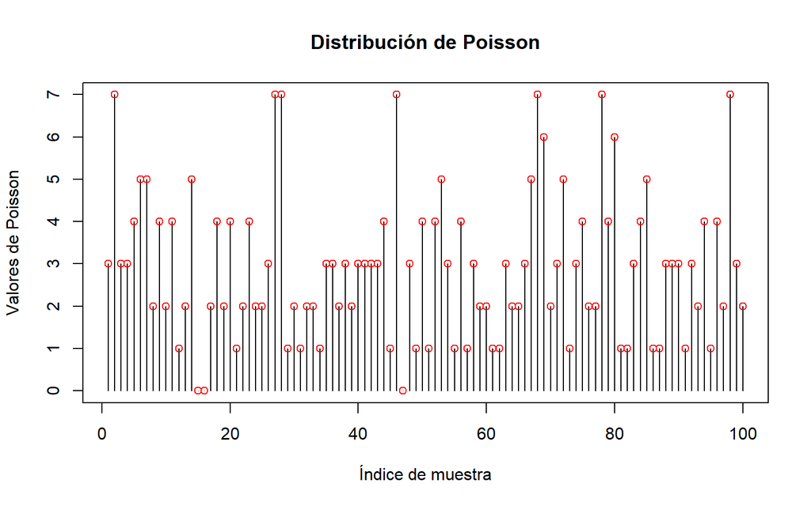

```r
plot(poisson_result, type = "h", main = "Distribución de Poisson", xlab = "Índice de muestra", ylab = "Valores de Poisson")
points(poisson_result, col = "red")
```

- Distribución Geométrica.

```r
#representa el número de fracasos antes del primer éxito en una secuencia de ensayos de Bernoulli.
p <- 0.3
n <- 100
geometric_result <- rgeom(n, p)
geometric_result
```

```
##   [1]  1  6  3  1  0  1  1  2 10  0  1  0  1  2  0  0  2  0  3  0  3 12  0  2  2
##  [26]  0  1  0  3  2  2  0  0  0  2  0  4  1  3 16  0  2  1  0  0  0  1  1  3  6
##  [51]  0  5  2  0 13  3  2  0  3  1  3  2  2  0  5  8  3  0  2 12  0  6  3  3  0
##  [76]  0  6  2  0  0  6  1  7  0  1  1  7  3  3  0  3  1  3  0  1  0  1  6  0  3
```

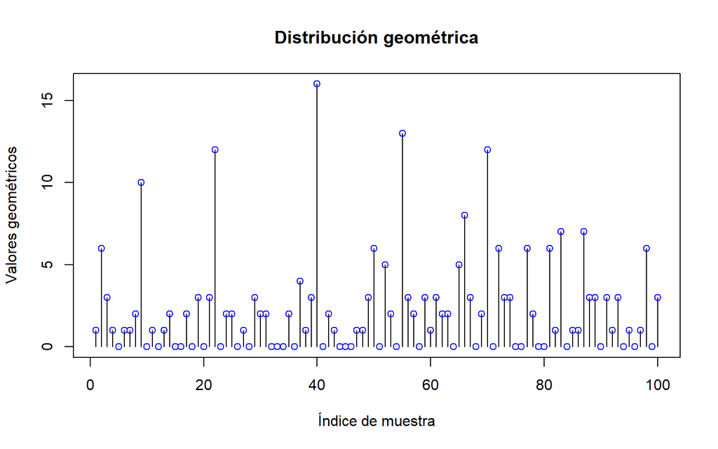

```r
plot(geometric_result, type = "h", main = "Distribución geométrica", xlab = "Índice de muestra", ylab = "Valores geométricos")
points(geometric_result, col = "blue")
```

- Distribución Uniforme discreta.

```r
#La distribución uniforme discreta asigna igual probabilidad a todos los valores enteros dentro de un rango especificado. Sus parámetros clave son el mínimo y el máximo del rango.

min_value <- 1
max_value <- 10
n <- 100
uniform_result <- sample(min_value:max_value, n, replace = TRUE)
uniform_result
```

```
##   [1]  9  6  3  4  4 10  7 10  4  3  3 10  3  8  3  9  3  7  5  3  2  5  6 10  7
##  [26]  4  6  6  5  9  9  8  3  1  7  7  9  5  3  2  6  3  8  7  4 10  2  6  5  3
##  [51]  6  7  4  8  2  4  3  3 10  7  1  7  6  6  2  5  1  2  8  1 10 10 10  2  8
##  [76]  3  5  6  5  4  6  4  5  6  6  6  4 10 10 10  9  6  8  3  7  1  8  4  9  4
```

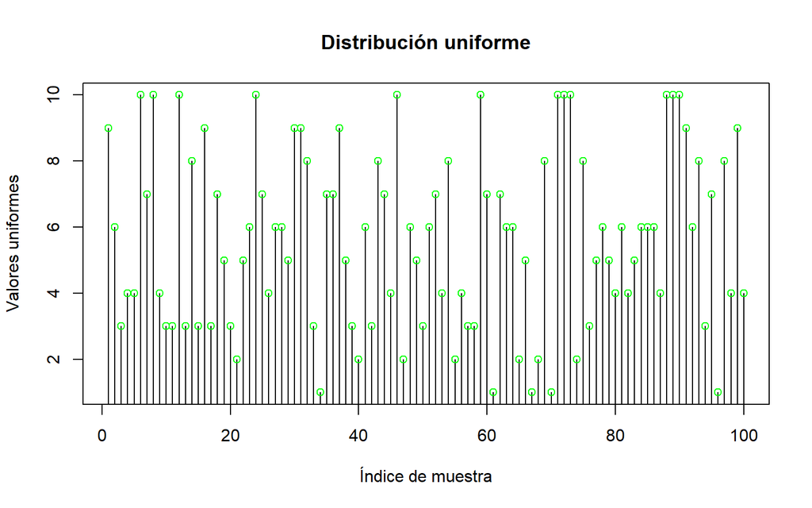

```r
plot(uniform_result, type = "h", main = "Distribución uniforme", xlab = "Índice de muestra", ylab = "Valores uniformes")
points(uniform_result, col = "green")
```

- Distribución Hipergeométrica.

```r
#una distribución de probabilidad discreta que se utiliza para modelar el número de elementos de una muestra de tamaño n extraídos de una población de tamaño N que contiene M elementos de una clase particular.

hyper_data <- rhyper(nn = 10, m = 30, n = 10, k = 5)#Genera 10 valores aleatorios de la distribución hipergeométrica
hyper_data
```

```
##  [1] 4 3 4 3 2 2 4 5 3 4
```

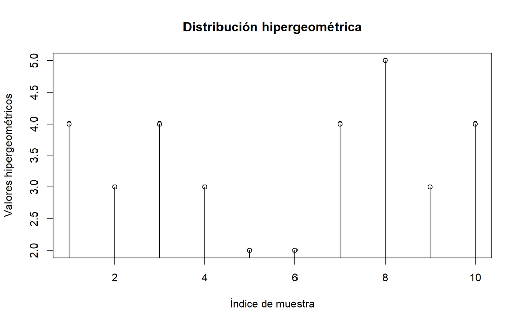

```r
plot(hyper_data, type = "h", main = "Distribución hipergeométrica", xlab = "Índice de muestra", ylab = "Valores hipergeométricos")
points(hyper_data)
```

## Distribuciones continuas

En probabilidad los datos pueden ser continuos y discretos, cuando son discretos los modelamos mediante distribuciones discretas mientras si los datos tienen un continuo de valores, entonces se tienen que modelar mediante distribuciones de probabilidad continuas. Un ejemplo clásico de distribución continua es la distribución normal o Gaussiana. Las distribuciones continuas igual se representan mediante ecuaciones y en esto caso pueden ser representados por funciones llamadas PDFs o CDFs. A continuación definimos algunas de ellas.

### Distribución Gaussiana o normal

Se dice que los datos son Gaussianos cuando éstos vinieron de una distribución Gaussiana, la cual tiene la siguiente forma:

$$f(x) = \frac{1}{\sqrt{2\pi
\sigma^2}}\mbox{e}^{\frac{-(x-\mu)^2}{2\sigma^2}}$$

En `R` esta distribución de puede simular como:

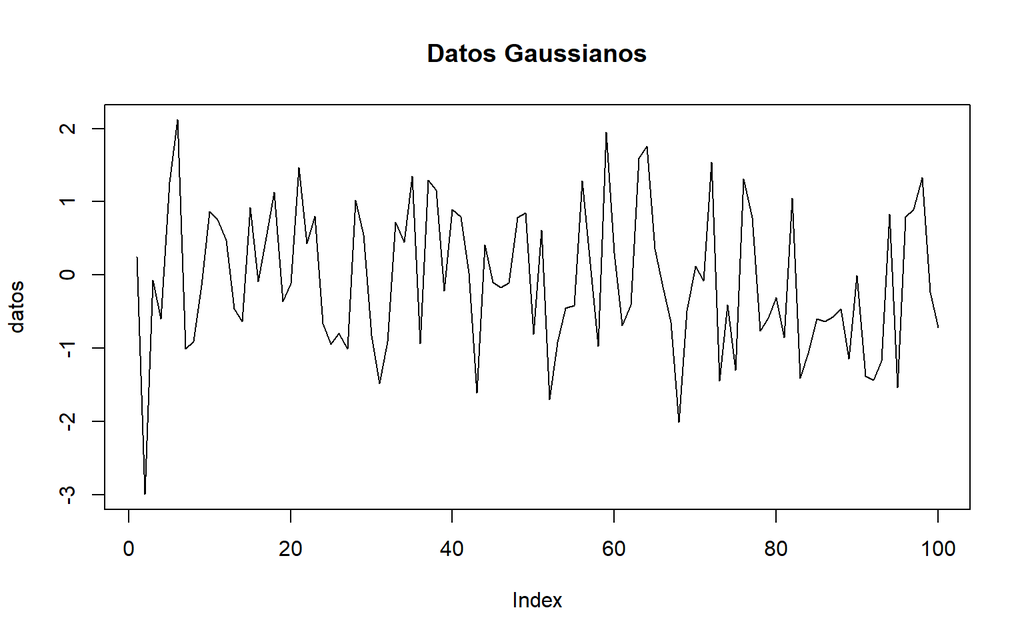

```r
datos <- rnorm(100,mean=0, sd=1)
plot(datos, type="l", main="Datos Gaussianos")
```

Existen muchas otras distribuciones continuas y el objetivo de ellas es adecuar nuestros datos a una de ellas con el objetivo de simular situaciones con valores tomados de ellas.

### Tarea

Investigar las siguientes distribuciones continuas de probabilidad (pueden incorporar el código en `R` que las genera aunque es opcional).

- Distribución uniforme continua.

```r
#La distribución uniforme continua es una distribución de probabilidad en la que todos los valores posibles tienen la misma probabilidad de ocurrencia dentro de un intervalo.

ejem_DUC <- runif(n = 10, min = 0, max = 1)
print(ejem_DUC)
```

```
##  [1] 0.64839823 0.96993354 0.58059273 0.85442431 0.12003906 0.79274760
##  [7] 0.10850332 0.07824265 0.86023739 0.36225812
```

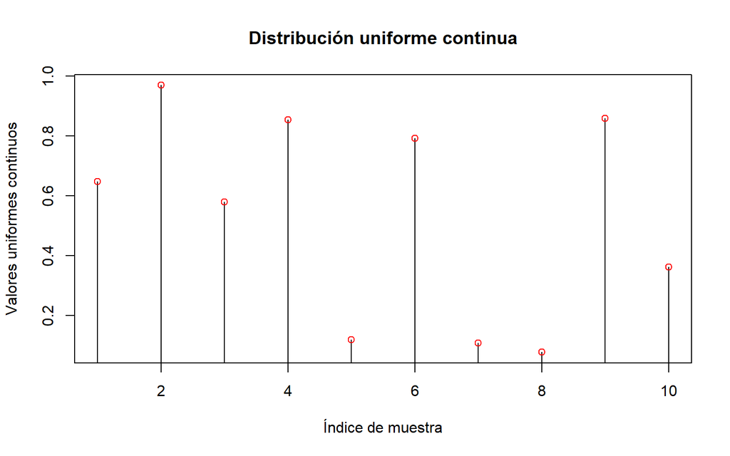

```r
plot(ejem_DUC, type = "h", main = "Distribución uniforme continua", xlab = "Índice de muestra", ylab = "Valores uniformes continuos")
points(ejem_DUC, col = "red")
```

- Distribución exponencial.

```r
#se utiliza para modelar el tiempo entre eventos que ocurren de manera aleatoria e independiente a una tasa constante.

set.seed(123)
datos_exponenciales <- rexp(n = 10, rate = 0.5)
datos_exponenciales
```

```
##  [1] 1.68691452 1.15322054 2.65810974 0.06315472 0.11242195 0.63300243
##  [7] 0.62845458 0.29053361 5.45247293 0.05830689
```

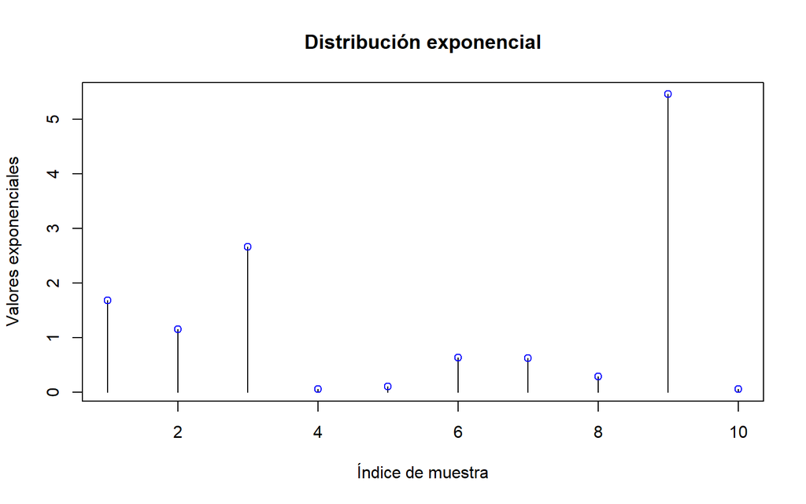

```r
plot(datos_exponenciales, type = "h", main = "Distribución exponencial", xlab = "Índice de muestra", ylab = "Valores exponenciales")
points(datos_exponenciales, col = "blue")
```

- Distribución Rayleigh

```r
# La distribución Rayleigh se utiliza para modelar la magnitud de una variable aleatoria que es la suma de dos variables aleatorias independientes con distribución normal.

set.seed(123)
n <- 100 #es el número de valores aleatorios a generar
sigma <- 2 #el parámetro de escala de la distribución Rayleigh
datos_rayleigh <- rweibull(n,shape = 2, scale = sigma)#shape es el parámetro de forma
datos_rayleigh
```

```
##   [1] 2.2327228 0.9754384 1.8911336 0.7054371 0.4954934 3.5149976 1.5980729
##   [8] 0.6747428 1.5430247 1.7707798 0.4201240 1.7789050 1.2477844 1.4933312
##  [15] 3.0157969 0.6497846 2.3681783 3.5601512 2.1118555 0.4315730 0.6842560
##  [22] 1.2116254 1.3349090 0.1516140 1.2992968 1.1739884 1.5603649 1.4431035
##  [29] 2.2278025 2.7687903 0.3882098 0.6412777 1.2166217 0.9567139 3.8493910
##  [36] 1.7188036 1.0516004 2.4743404 2.1402195 2.4187866 2.7902043 1.8767744
##  [43] 1.8788884 1.9973758 2.7429568 2.8104644 2.4137692 1.7477417 2.3016184
##  [50] 0.7832037 3.5115757 1.8066464 0.9476041 2.9014206 1.5206934 2.5118144
##  [57] 2.8701155 1.0644835 0.6659756 1.9821835 1.2771766 3.0695648 1.9567236
##  [64] 2.2744036 0.9055582 1.7908771 0.9179141 0.9116477 0.9596682 1.8125818
##  [71] 1.0615704 1.3612825 1.1700144 5.4325396 1.7248469 2.4605589 1.9678079
##  [78] 1.3996628 2.0442098 2.9644600 2.3766765 1.2702502 1.8688170 0.9757227
##  [85] 3.0161839 1.8249996 0.2462301 0.6726409 0.6942883 2.6402034 2.8529869
##  [92] 1.3054073 2.0673850 1.2968261 2.1337934 2.5868573 0.9910081 3.0781673
##  [99] 1.7457368 1.6375555
```

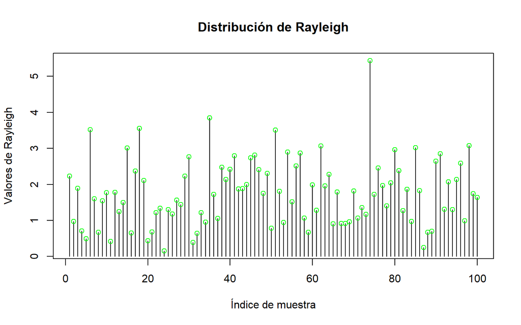

```r
plot(datos_rayleigh, type = "h", main = "Distribución de Rayleigh", xlab = "Índice de muestra", ylab = "Valores de Rayleigh")
points(datos_rayleigh, col = "green")
```

- Distribución Gamma.

```r
#La distribución gamma se utiliza para modelar el tiempo de espera hasta que se produzcan un número determinado de eventos que ocurren de manera aleatoria e independiente a una tasa constante.

DG <- rgamma(n = 10, shape = 2, rate = 0.5)
DG
```

```
##  [1] 3.6525862 2.9304825 6.7634099 3.7142112 0.9807201 0.4056635 0.9514019
##  [8] 3.5522620 4.0019861 1.8957283
```

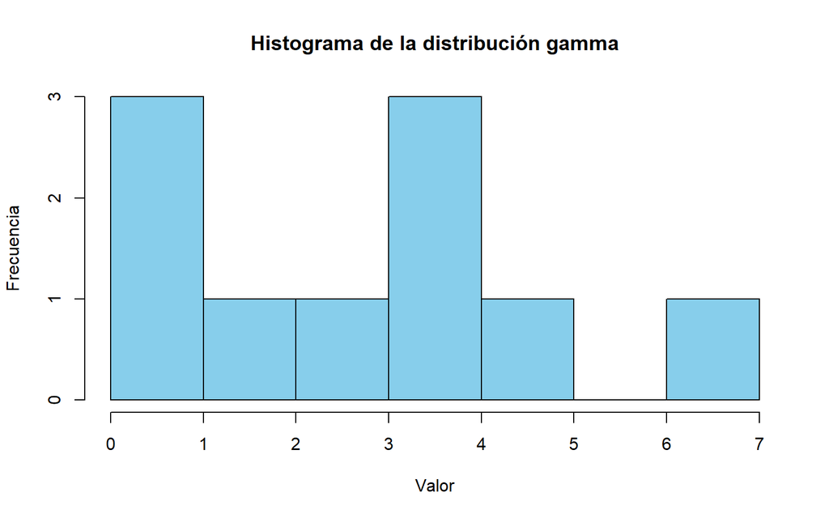

```r
hist(DG, main="Histograma de la distribución gamma", xlab="Valor", ylab="Frecuencia", col="skyblue")
```

La tarea se debe entregar el día Miércoles 18 de octubre de 2023. Atte. Dr. Julio César Ramírez Pacheco.